# qyobo_task_shiny_results

```python
# automatically show plots inside the notebook
%matplotlib inline

# reload all modules before executing code
%load_ext autoreload
%autoreload 2
```

```python
import pandas as pd
import numpy as np
import matplotlib.pylab as plt
import seaborn as sns

from sklearn.metrics import classification_report
from sklearn.linear_model import LogisticRegression
from sklearn.model_selection import GridSearchCV, train_test_split
from sklearn.pipeline import make_pipeline
from sklearn.manifold import TSNE
from sklearn.preprocessing import StandardScaler
from sklearn.decomposition import PCA

RANDOM_STATE = 42
```

## Analysis

```python
# let's use first column as index noting that test starts from 40000, so right after end of the train index

train = pd.read_csv('./data/labeled.csv', index_col=0)
test = pd.read_csv('./data/test.csv', index_col=0)

test_answers = pd.read_csv('./data/key.csv', index_col=0)
```

```python
# just to check constistency of the data

print("Train shape: ", train.shape)
print("Test shape: ", test.shape)
print("Test answers shape: ", test_answers.shape)
```

```
Train shape:  (40000, 43)
Test shape:  (10000, 42)
Test answers shape:  (10000, 1)
```

```python
train.head(2)
```

|  | product_ID | ft0 | ft1 | ft2 | ft3 | ft4 | ft5 | ft6 | ft7 | ft8 | ... | ft32 | ft33 | ft34 | ft35 | intro_date | relise_date | market | AAZ | 3LCC | company_ID |
| --- | --- | --- | --- | --- | --- | --- | --- | --- | --- | --- | --- | --- | --- | --- | --- | --- | --- | --- | --- | --- | --- |
| 0 | 0ca659d4-ac15-11ea-8082-e4b3180e5d76 | 75.214796 | 109.802174 | 5.788292 | 95.213961 | 289.355062 | 222.500733 | 3.820438 | 561.546501 | 1799.716462 | ... | 41.616993 | 57.143985 | 34.595151 | 54.213477 | 1994-07-07 | 1994-07-14 | Bolivia | 26916 | LLG | 3 |
| 1 | 0cac7158-ac15-11ea-9db8-e4b3180e5d76 | 77.486585 | 110.566696 | 4.246617 | 94.639143 | 261.068060 | 201.876990 | 19.565938 | 35.613997 | 4.633782 | ... | 38.731049 | 38.877021 | 60.274508 | 51.344132 | 2002-05-11 | 2002-05-21 | Somalia | 3504 | QRP | 0 |

2 rows × 43 columns

```python
test.head(2)
```

|  | product_ID | ft0 | ft1 | ft2 | ft3 | ft4 | ft5 | ft6 | ft7 | ft8 | ... | ft31 | ft32 | ft33 | ft34 | ft35 | intro_date | relise_date | market | AAZ | 3LCC |
| --- | --- | --- | --- | --- | --- | --- | --- | --- | --- | --- | --- | --- | --- | --- | --- | --- | --- | --- | --- | --- | --- |
| 40000 | 0c970aa4-ac15-11ea-84e1-e4b3180e5d76 | 70.618330 | 109.395468 | 62.946456 | 96.767709 | 273.511462 | 214.202147 | 20.878927 | 29.315263 | 10712.653876 | ... | 32.979143 | 45.014508 | 43.342661 | 53.972471 | 53.988734 | 1980-12-29 | 1981-01-14 | Sri Lanka | 51991 | LLG |
| 40001 | 0ca20dbe-ac15-11ea-ad80-e4b3180e5d76 | 73.888212 | 109.930820 | 2.516169 | 94.258624 | 291.005971 | 209.920292 | 658.113244 | 76.611168 | 24.757528 | ... | 40.350564 | 34.868359 | 53.084930 | 38.075714 | 50.166952 | 2010-01-25 | 2010-02-04 | Afghanistan | 2377 | P1N |

2 rows × 42 columns

```python
test_answers.head(2)
```

|  | true_label |
| --- | --- |
| 0 | 0 |
| 1 | 3 |

```python
# after first examination above, let's just add answers to the test to deal with two dataframes instead of three

test['company_ID'] = test_answers['true_label'].values
```

```python
# the data seems pretty balanced for train

train['company_ID'].value_counts()
```

```
1    10023
3     9994
2     9993
0     9990
Name: company_ID, dtype: int64
```

```python
# the data seems balanced for test as well

test['company_ID'].value_counts()
```

```
0    2510
2    2507
3    2506
1    2477
Name: company_ID, dtype: int64
```

Let's check nulls both in train and test. We don't have any missing data.

```python
for col in train.columns:
    if train[col].isnull().any():
        print('{0} , null_count : {1}'.format(col, train[col].isnull().sum()))

for col in test.columns:
    if test[col].isnull().any():
        print('{0} , null_count : {1}'.format(col, test[col].isnull().sum()))
```

```python
# as promised we have 36 numerical features

train.dtypes.value_counts()
```

```
float64    36
object      5
int64       2
dtype: int64
```

```python
# AAZ doesn't seem very categorical in its nature

train['AAZ'].value_counts()
```

```
62355    5
65143    5
27692    5
96068    5
94788    5
        ..
22623    1
43105    1
45154    1
36966    1
65536    1
Name: AAZ, Length: 32807, dtype: int64
```

```python
# 3LCC is a categorical feature

for col in train.columns:
    if  (train[col].value_counts().shape[0] < 100):
        print(col)
```

```
3LCC
company_ID
```

Let's look at that feature in relation to company_ID, it seems that they are correlated

```python
train[['3LCC', 'company_ID']].head(10)
```

|  | 3LCC | company_ID |
| --- | --- | --- |
| 0 | LLG | 3 |
| 1 | QRP | 0 |
| 2 | P1N | 1 |
| 3 | FFP | 2 |
| 4 | QRP | 0 |
| 5 | LLG | 3 |
| 6 | P1N | 1 |
| 7 | QRP | 0 |
| 8 | FFP | 2 |
| 9 | P1N | 1 |

But on the test, the same LLG has company_ID 0 and not 3, which can fool the model but not us:)

```python
test[['3LCC', 'company_ID']].head(10)
```

|  | 3LCC | company_ID |
| --- | --- | --- |
| 40000 | LLG | 0 |
| 40001 | P1N | 3 |
| 40002 | LLG | 1 |
| 40003 | QRP | 2 |
| 40004 | QRP | 3 |
| 40005 | LLG | 3 |
| 40006 | P1N | 0 |
| 40007 | LLG | 2 |
| 40008 | P1N | 3 |
| 40009 | LLG | 3 |

```python
train['3LCC'].value_counts()
```

```
P1N    10023
LLG     9994
FFP     9993
QRP     9990
Name: 3LCC, dtype: int64
```

```python
# we see that 3LCC is highly correlated with company ID

train_for_corr = train.copy()

for col in train_for_corr.columns:
    if col != 'company_ID':
        train_for_corr[col] =train_for_corr[col].astype('category').cat.codes

train_for_corr.corr()['company_ID'].abs().sort_values(ascending=False)
```

```
company_ID     1.000000
3LCC           0.799998
ft33           0.661181
ft34           0.615483
ft31           0.504545
ft30           0.159706
ft35           0.068108
ft32           0.060785
ft10           0.012893
ft22           0.009324
ft5            0.009212
ft0            0.009031
ft14           0.008706
ft7            0.008639
ft8            0.007330
ft20           0.007272
ft19           0.007227
ft18           0.006970
ft17           0.006956
ft15           0.005590
intro_date     0.005156
relise_date    0.005130
ft24           0.005049
ft21           0.004712
ft3            0.004636
product_ID     0.004634
ft2            0.004345
ft9            0.003979
ft16           0.003966
ft11           0.003560
ft1            0.003544
AAZ            0.003524
ft12           0.003322
market         0.002913
ft6            0.002156
ft25           0.002065
ft23           0.001824
ft29           0.001689
ft13           0.001685
ft27           0.001645
ft28           0.001582
ft26           0.000595
ft4            0.000040
Name: company_ID, dtype: float64
```

This correlation for 3LCC doesn't hold for test and we should exclude that feature but ft33, ft34 and ft31 seem pretty reliable in both train and test

```python
test_for_corr = test.copy()

for col in test_for_corr.columns:
    if col != 'company_ID':
        test_for_corr[col] = test_for_corr[col].astype('category').cat.codes

test_for_corr.corr()['company_ID'].abs().sort_values(ascending=False)
```

```
company_ID     1.000000
ft33           0.668373
ft34           0.616709
ft31           0.507968
ft30           0.156046
ft35           0.071737
ft32           0.068903
ft5            0.025039
ft9            0.020059
ft22           0.016121
ft11           0.016086
ft12           0.015367
ft2            0.012471
ft6            0.010552
ft29           0.010071
ft3            0.009788
ft25           0.009190
ft19           0.008434
AAZ            0.007200
ft17           0.007130
ft7            0.006323
ft16           0.006234
ft0            0.006146
3LCC           0.006103
ft23           0.006098
ft21           0.005386
ft28           0.004936
relise_date    0.004451
intro_date     0.004410
ft13           0.004260
ft20           0.004099
ft4            0.003487
ft27           0.003356
ft1            0.002554
ft26           0.001829
ft10           0.001550
ft24           0.000640
ft8            0.000626
ft18           0.000591
ft15           0.000522
product_ID     0.000454
ft14           0.000065
market         0.000045
Name: company_ID, dtype: float64
```

We can see that some numeric features are correlated. If I had more time I would look into that:)

# Some visuals

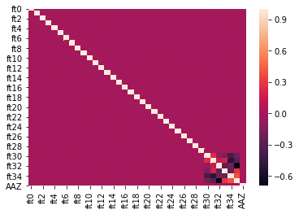

```python
corr_matrix = train.drop(['company_ID'], axis=1).corr()

sns.heatmap(corr_matrix);
```

```python
# let's get only numeric features (36 of them) to plot some visualisations

df_num = train.select_dtypes(include=[np.float])
```

```python
%%time

# Let's scale first

scaler = StandardScaler()
feature_columns = df_num.columns # we exclude spoiler column 3LCC
merged_df_scaled = scaler.fit_transform(train[feature_columns])

# Then apply PCA with 5 features for example

pca = PCA(n_components=5, random_state=RANDOM_STATE)
pca_representation = pca.fit_transform(merged_df_scaled)

# Then use t-SNE from sklearn. Though it's not that efficient (there is another open-source lib with much better
# performance and flexibility) we can use it to get a sense of the data

tsne = TSNE(learning_rate=300, random_state=RANDOM_STATE)
tsne_representation = tsne.fit_transform(pca_representation)
```

```
CPU times: user 23min 49s, sys: 21.2 s, total: 24min 10s
Wall time: 7min 31s
```

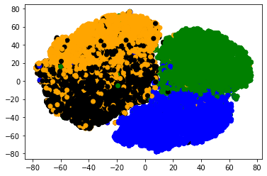

```python
plt.scatter(tsne_representation[:, 0], tsne_representation[:, 1],
            c=train["company_ID"].map({0: 'blue', 1: 'orange', 2: 'black', 3: 'green'}));
```

# A bit of ML

What we need to train a model?

- lets ignore ID (it is possible that product_ID hides a hashed reference to the company but we can work on that later or ignore that as it can be time consuming)
- intro_date, release date -- we can play with time features here but we are short in time and it doesn't seem as key to success in this task:)
- 3LCC as a spoiled feature

```python
cols_to_ignore = ['intro_date',
                  'relise_date',
                  'product_ID',
                  'company_ID',  # target column
                  '3LCC'
                 ]

feature_columns = [col for col in train.columns if col not in cols_to_ignore]
cat_cols = ['market']
```

```python
train[feature_columns].head(2)
```

|  | ft0 | ft1 | ft2 | ft3 | ft4 | ft5 | ft6 | ft7 | ft8 | ft9 | ... | ft28 | ft29 | ft30 | ft31 | ft32 | ft33 | ft34 | ft35 | market | AAZ |
| --- | --- | --- | --- | --- | --- | --- | --- | --- | --- | --- | --- | --- | --- | --- | --- | --- | --- | --- | --- | --- | --- |
| 0 | 75.214796 | 109.802174 | 5.788292 | 95.213961 | 289.355062 | 222.500733 | 3.820438 | 561.546501 | 1799.716462 | 263.539958 | ... | 4.913031 | 1324.306087 | 41.560957 | 35.916460 | 41.616993 | 57.143985 | 34.595151 | 54.213477 | Bolivia | 26916 |
| 1 | 77.486585 | 110.566696 | 4.246617 | 94.639143 | 261.068060 | 201.876990 | 19.565938 | 35.613997 | 4.633782 | 267.974720 | ... | 5.271699 | 1.503881 | 32.213349 | 34.025343 | 38.731049 | 38.877021 | 60.274508 | 51.344132 | Somalia | 3504 |

2 rows × 38 columns

We don't want to induce any bias with LabelEncoder on the categorical features, so we use simple OneHot to encoder categories

```python
one_hot_train = pd.get_dummies(train[feature_columns], prefix_sep='_', drop_first=True, columns=cat_cols)
```

```python
one_hot_train.head(2)
```

|  | ft0 | ft1 | ft2 | ft3 | ft4 | ft5 | ft6 | ft7 | ft8 | ft9 | ... | market_Uruguay | market_Uzbekistan | market_Vanuatu | market_Venezuela | market_Vietnam | market_Wallis and Futuna | market_Western Sahara | market_Yemen | market_Zambia | market_Zimbabwe |
| --- | --- | --- | --- | --- | --- | --- | --- | --- | --- | --- | --- | --- | --- | --- | --- | --- | --- | --- | --- | --- | --- |
| 0 | 75.214796 | 109.802174 | 5.788292 | 95.213961 | 289.355062 | 222.500733 | 3.820438 | 561.546501 | 1799.716462 | 263.539958 | ... | 0 | 0 | 0 | 0 | 0 | 0 | 0 | 0 | 0 | 0 |
| 1 | 77.486585 | 110.566696 | 4.246617 | 94.639143 | 261.068060 | 201.876990 | 19.565938 | 35.613997 | 4.633782 | 267.974720 | ... | 0 | 0 | 0 | 0 | 0 | 0 | 0 | 0 | 0 | 0 |

2 rows × 279 columns

Let's have a nice train-test split and as we have okayish amount of data we can try to get a less biased estimate on holdout by doing CV on the train

```python
X_train, X_test, y_train, y_test = train_test_split(one_hot_train,
                                                    train["company_ID"],
                                                    stratify=train["company_ID"],
                                                    test_size=0.25, random_state=RANDOM_STATE)
```

We will use recall as main metric for CV as recall + precision pair has a nice business interpretation.

```python
# Scale features for better convergence

scaler = StandardScaler()

C_values = [0.001, 0.01, 0.05, 0.1]

param_grid = {'logisticregression__C': C_values,
              'logisticregression__penalty': ['l1', 'l2']}

clf = LogisticRegression(solver='liblinear', random_state=RANDOM_STATE, multi_class='auto')

pipeline = make_pipeline(scaler, clf)

estimator = GridSearchCV(pipeline, param_grid=param_grid, scoring='recall_micro', cv=3)
estimator.fit(X_train, y_train)

print("Mean recall for the 1 class across the folds on cv: {0} \n".format(estimator.best_score_))
print("Best estimator: \n {0} \n".format(estimator.best_estimator_))
print("Classification report for holdout: \n", classification_report(y_test,
                                                                    estimator.best_estimator_.predict(X_test)))
```

```
Mean recall for the 1 class across the folds on cv: 0.9822

Best estimator:
 Pipeline(memory=None,
         steps=[('standardscaler',
                 StandardScaler(copy=True, with_mean=True, with_std=True)),
                ('logisticregression',
                 LogisticRegression(C=0.05, class_weight=None, dual=False,
                                    fit_intercept=True, intercept_scaling=1,
                                    l1_ratio=None, max_iter=100,
                                    multi_class='auto', n_jobs=None,
                                    penalty='l1', random_state=42,
                                    solver='liblinear', tol=0.0001, verbose=0,
                                    warm_start=False))],
         verbose=False)

Classification report for holdout:
               precision    recall  f1-score   support

           0       0.99      0.99      0.99      2498
           1       0.97      0.97      0.97      2506
           2       0.98      0.97      0.97      2498
           3       0.99      0.99      0.99      2498

    accuracy                           0.98     10000
   macro avg       0.98      0.98      0.98     10000
weighted avg       0.98      0.98      0.98     10000
```

```python
one_hot_test = pd.get_dummies(test[feature_columns], prefix_sep='_', drop_first=True, columns=cat_cols)
```

```python
print("Classification report for holdout: \n", classification_report(test['company_ID'],
                                                                    estimator.best_estimator_.predict(one_hot_test)))
```

```
Classification report for holdout:
               precision    recall  f1-score   support

           0       0.99      0.99      0.99      2510
           1       0.97      0.97      0.97      2477
           2       0.97      0.97      0.97      2507
           3       0.99      0.99      0.99      2506

    accuracy                           0.98     10000
   macro avg       0.98      0.98      0.98     10000
weighted avg       0.98      0.98      0.98     10000
```

# Conclusion

Few things I would like to explore more but didn't have much time for that:

1. Explore correlations between numerical features
2. Explore 3LCC feature -- if it is a problem somewhere in a data acquiring pipeline it can be worth to look into
3. Add feature contribution analysis, it can help to reduce dimensionality and make an easier model which is alway good
4. Try other models -- just maybe as classics works quite good:)